```python
%%HTML
<style type="text/css">
    h1{
        color:red;
        font-style:italic;
    }
    .code{
        background-color:gray;
        color:blue;
        white-sapce: pre;
    }
    .notice{
        font-weight:bold;
    }
    .outline{
        background-color:blueviolet;
        color:white;
}
</style>
```

# 梗概

### 添加x,y刻度

- - plt.xticks()
  - plt.yticks()
  - 注意:在传递进去的第一个参数必须是数字,不能是字符串,如果是字符串，需要进行替换操作

### 添加网格显示

- - plt.grid(linestyle="--",alpha=0.5)

### 添加描述信息

- - plt.xlabel()
  - plt.ylabel()
  - plt.title()

### 图像保存

- - plt.savefig("文件路径")

### 多次plot

- - 多次plt.plot()就行

### 显示图例

- - plt.legend(loc="指定的位置"/loc=0-10对应位置)
  - 注意:一定要在plt.plot()里面设置一个label,如果不设置就没法显示

### 多个坐标系显示

- - plt.subplot(nrows=,ncols=,figsize=(),dpi=)

### 折线图的使用

- - 应用与观察数据的变化
  - 可以画出函数图像

# 多个坐标显示-plt.subplots(面向对象的画图方法)

如果我们想要将上海和北京的天气图像显示在同一个图的不同坐标系中  
可以通过subplots函数实现(旧的版本中有subplot,使用起来不方便，推荐使用subplots函数)

- matplotlib.pyplot.subplots(nrows=1,ncols=1,**fig_kw)创建一个带有多个axes(坐标系绘图区)的图

  ```
          Parameters:
          nrows,ncols:设置有几行几列坐标系
          int,optional,default: 1; Number of rows/columns of the subplot grid,


      Returns:
      fig:图对象
      axes:返回相应数量的坐标系,其中axes英文意思为轴线

      设置标题等方法不同:
          set_xticks
          set_yticks
          set_xlabel
          set_ylabel
  ```

  关于axes子坐标轴的更多方法，参考[官方网站](https://matplotlib.org/api/axes_api.html#matplotlib.axes.Axes)

注意:plt.函数名()相当于面向过程的画图方法,axes.set_方法是面向对象的画图方法

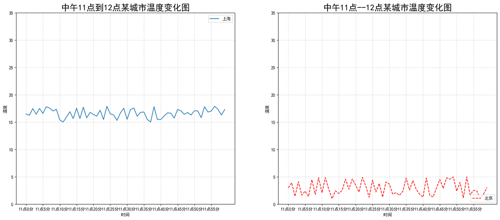

```python
#导包
from matplotlib import pyplot as plt
from pylab import mpl
import random
# 设置显示中文字体
mpl.rcParams["font.sans-serif"] = ["SimHei"]
# 解决部分字符无法正常显示的问题
mpl.rcParams["axes.unicode_minus"]=False

# 0 数据准备
x=range(60)
y_shanghai=[random.uniform(15,18) for i in x]
y_beijing=[random.uniform(1,5) for i in x]

# 1 创建画布
# plt.figure(figsize=(20,8),dpi=100)
fig,axes = plt.subplots(nrows=1,ncols=2,figsize=(20,8),dpi=100)

# 2 绘制图像
# plt.plot(x,y_shanghai,label="上海",fontsize=20)
# plt.plot(x,y_beijing,label="北京",fontsize=20)
axes[0].plot(x,y_shanghai,label="上海")
axes[1].plot(x,y_beijing,color='r',linestyle='--',label="北京")

# 2.1 添加x,y轴刻度
x_ticks_label=["11点{}分".format(i) for i in x]
y_ticks=range(40)


# 刻度显示
# plt.xticks(x[::5],x_ticks_label[::5])
# plt.yticks(y_ticks[::5])
axes[0].set_xticks(x[::5])
axes[0].set_yticks(y_ticks[::5])
axes[0].set_xticklabels(x_ticks_label[::5])
axes[1].set_xticks(x[::5])
axes[1].set_yticks(y_ticks[::5])
axes[1].set_xticklabels(x_ticks_label[::5])

# 2.2添加网格显示
# plt.grid(True,linestyle='--',alpha=0.5)
axes[0].grid(True,linestyle='--',alpha=0.5)
axes[1].grid(True,linestyle='--',alpha=0.5)

# 2.3 添加描述信息
# plt.xlabel("时间")
# plt.ylabel("温度")

axes[0].set_xlabel("时间")
axes[0].set_ylabel("温度")
axes[0].set_title("中午11点到12点某城市温度变化图",fontsize=20)
axes[1].set_xlabel("时间")
axes[1].set_ylabel("温度")
axes[1].set_title("中午11点--12点某城市温度变化图",fontsize=20)

# 2.4图像保存
# plt.savefig("./demo.png")

# 2.5 添加图例
# plt.legend(loc="best")
axes[0].legend(loc="upper right")
axes[1].legend(loc="lower right")

# 3图像显示
plt.show()
```

## 折线图的应用场景

- 呈现公司产品每日活跃用户数
- 呈现app每天下载数量
- 呈现产品新功能上线后，用户点击次数随时间的变化
- 拓展:画各种数学函数图像
  - 注意:plt.plot()除了可以画折线图，也可用于画各种数学函数图像